# Analyzing Individual BGG Users

Phil Henrickson

2022-01-02

# **jhgf280’s** BoardGameGeek Collection

This notebook contains a set of analyses for the selected user’s boardgamegeek collection. The bulk of the analysis is focused on building a user-specific predictive model to predict the games that jhgf280 is likely to own. This enables to ask questions like, based on the games the user currently owns, what games are a good fit for their collection? What upcoming games are they likely to purchase?

This analysis is based on data from BoardGameGeek that was last updated on **2021-12-20.**

# 1 Collection Overview

We can look at a basic description of the number of games that the user owns, has rated, has previously owned, etc.

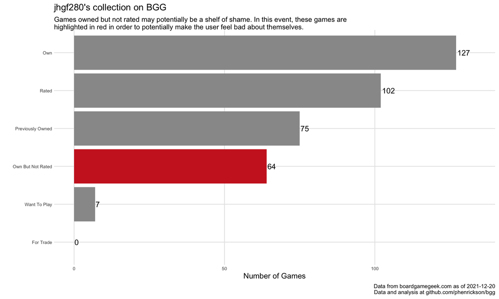

What years has the user owned/rated games from? While we can’t see when a user added or removed a game from their collection, we can look at their collection by the years in which their games were published.

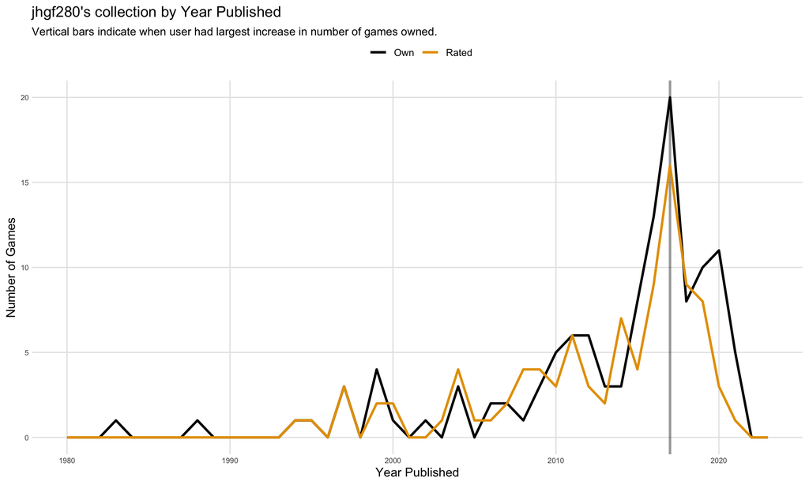

## 1.1 What types of games does jhgf280 own?

We can look at the most frequent types of categories, mechanics, designers, and artists that appear in a user’s collection.

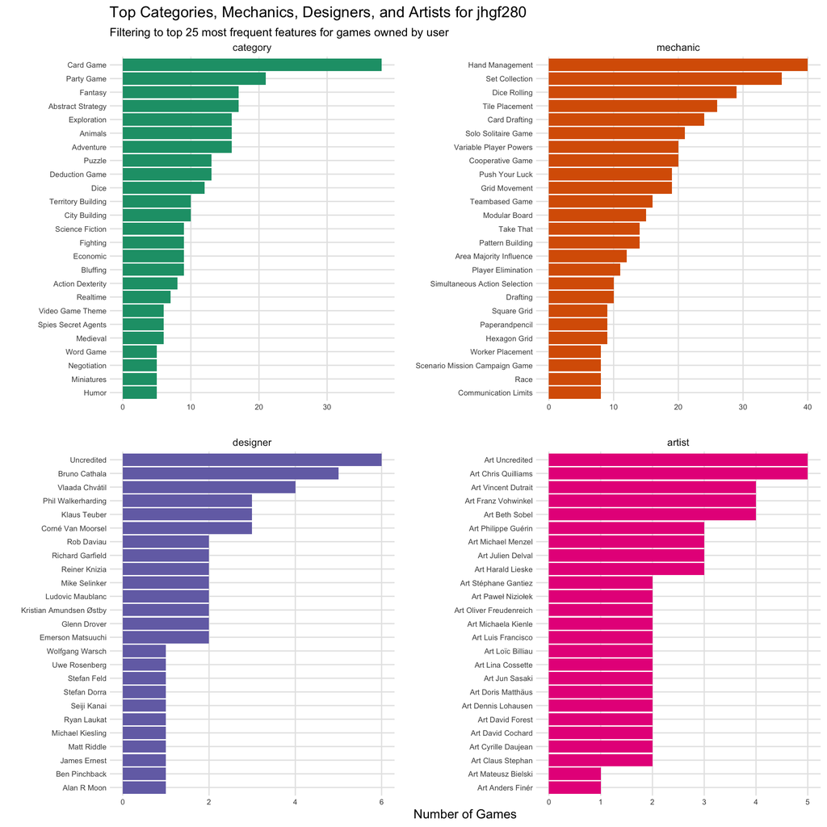

# 2 Modeling **jhgf280’s** Collection

| username | dataset | period | games_owned | games_rated | games_played |
| --- | --- | --- | --- | --- | --- |
| jhgf280 | training | published before 2020 | 110 | 98 | 196 |
| jhgf280 | test | published 2020 or later | 16 | 4 | 18 |

There are two main (binary) outcomes we will be modeling for the user.

The first, **own** refers to whether the user currently lists a game as owned in their collection. The second, **played** refers to whether the user currently owns, has rated, or previously owned a game. This means the latter will generally have a larger list of games, but may still be a useful category to examine for people who play lots of games without necessarily owning them.

We will train predictive models to learn the probability that the user will own or play individual games based on their features.

## 2.1 Coefficients for jhgf280

We can examine coefficients from the trained modes, which are penalized logistic regressions fit to our two main outcomes. Positive values indicate that a feature increases a user’s probabilility of owning/rating a game, while negative values indicate a feature decreases the probability.

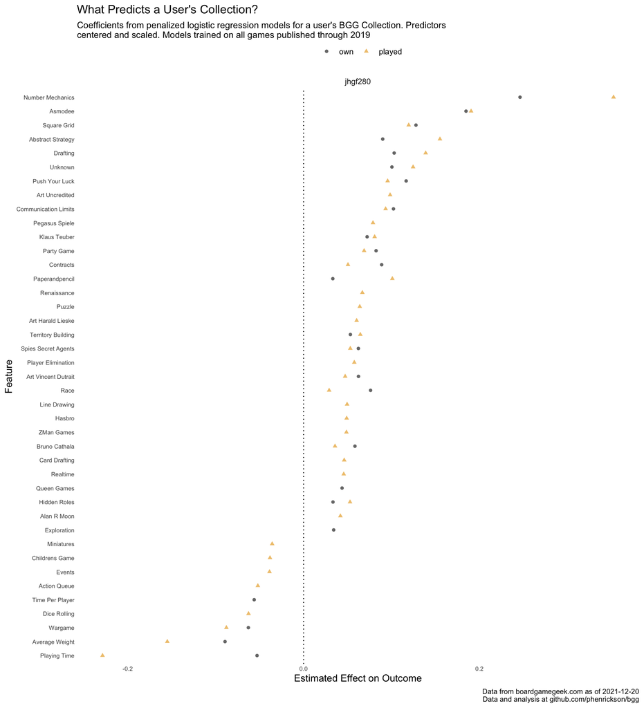

## 2.2 Visualizing Predictors for jhgf280’s Collection

Why did the model identify these features? We can make density plots of the important features for predicting whether the user owned a game. Blue indicates the density for games owned by the user, while grey indicates the density for games not owned by the user.

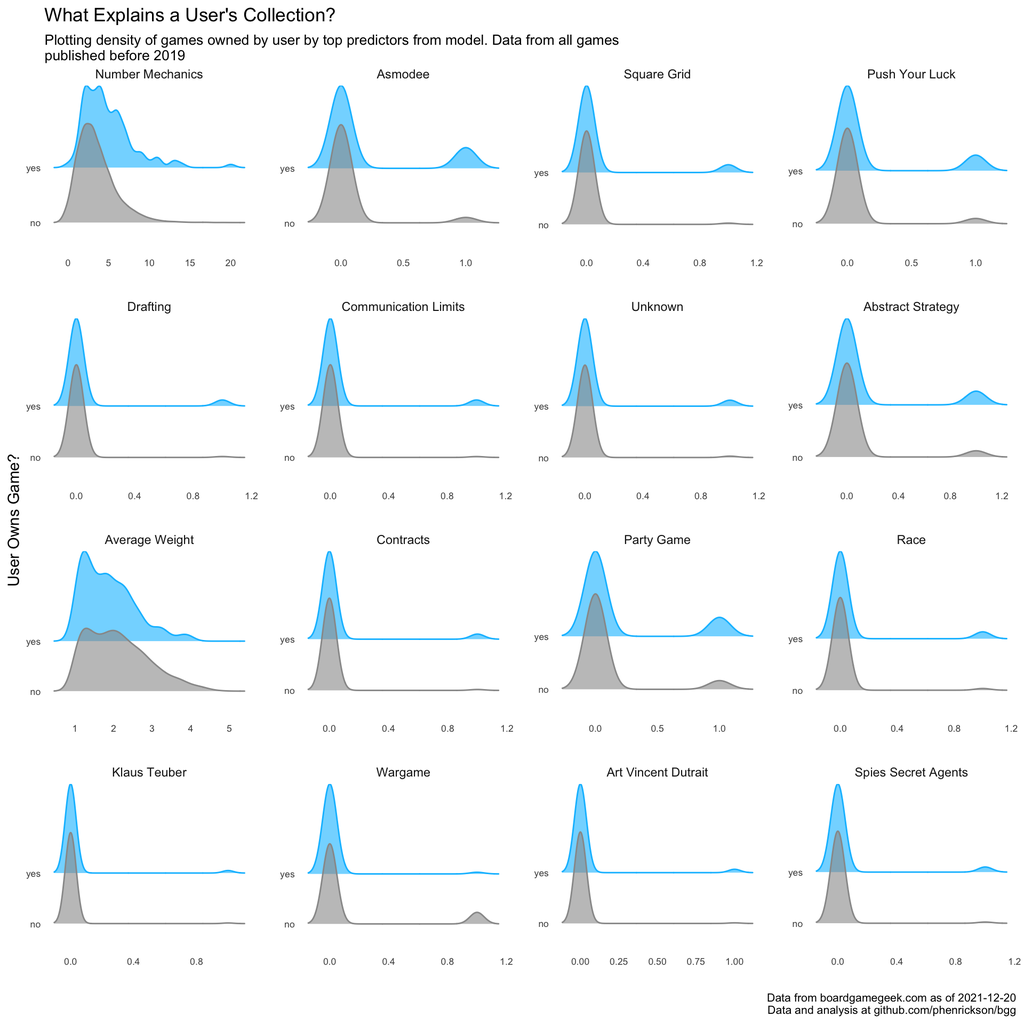

Binary predictors can be difficult to see with this visualization, so we can also directly examine the percentage of games in a user’s collection with a predictor vs the percentage of all games with that predictor.

| username | Feature | % of Games with Feature In_Collection | % of Games with Feature All_Games | Ratio |
| --- | --- | --- | --- | --- |
| jhgf280 | Communication Limits | 6.4% | 0.9% | 6.9 |
| jhgf280 | Drafting | 6.4% | 1.0% | 6.5 |
| jhgf280 | Square Grid | 8.2% | 1.3% | 6.1 |
| jhgf280 | Contracts | 5.5% | 1.0% | 5.6 |
| jhgf280 | Hidden Roles | 3.6% | 0.7% | 5.2 |
| jhgf280 | Unknown | 6.4% | 1.4% | 4.4 |
| jhgf280 | End Game Bonuses | 5.5% | 1.2% | 4.4 |
| jhgf280 | Spies Secret Agents | 5.5% | 1.3% | 4.3 |
| jhgf280 | Race | 7.3% | 1.8% | 4.0 |
| jhgf280 | Asmodee | 20.0% | 5.2% | 3.8 |
| jhgf280 | Push Your Luck | 15.5% | 5.2% | 3.0 |
| jhgf280 | Queen Games | 3.6% | 1.4% | 2.6 |
| jhgf280 | Player Elimination | 10.0% | 4.0% | 2.5 |
| jhgf280 | Paperandpencil | 6.4% | 2.6% | 2.4 |
| jhgf280 | Territory Building | 8.2% | 3.6% | 2.3 |
| jhgf280 | Iello | 7.3% | 3.1% | 2.3 |
| jhgf280 | Abstract Strategy | 13.6% | 6.2% | 2.2 |
| jhgf280 | Party Game | 18.2% | 8.3% | 2.2 |
| jhgf280 | Solo Solitaire Game | 12.7% | 5.9% | 2.2 |
| jhgf280 | Pegasus Spiele | 10.0% | 4.7% | 2.1 |
| jhgf280 | Exploration | 11.8% | 5.9% | 2.0 |
| jhgf280 | Tile Placement | 18.2% | 10.4% | 1.7 |
| jhgf280 | Card Drafting | 20.0% | 11.8% | 1.7 |
| jhgf280 | Wargame | 1.8% | 12.6% | 0.1 |
| jhgf280 | Track Movement | 0.0% | 0.7% | 0.0 |

# 3 Assess Model’s Performance on Training Set

Before predicting games in upcoming years, we can examine how well the model did and what games it liked in the training set. In this case, we used resampling techniques (cross validation) to ensure that the model had not seen a game before making its predictions.

## 3.1 Separation Plot

An easy way to examine the performance of classification model is to view a separation plot. We plot the predicted probabilities from the model for every game (from resampling) from lowest to highest. We then overlay a blue line for any game that the user does own. A good classifier is one that is able to *separate* the blue (games owned by the user) from the white (games not owned by the user), with most of the blue occurring at the highest probabilities (right side of the chart).

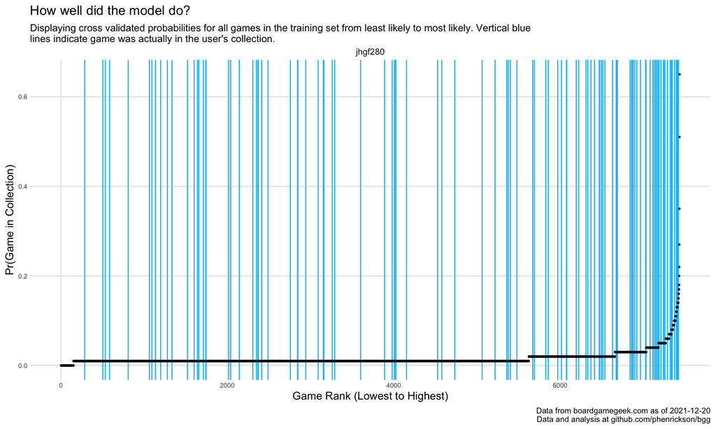

## 3.2 Top Games for **jhgf280** from Training Set

We can display this information in table form, displaying the 100 games with the highest probability of ownership, adding a blue line when the user does own the game.

| username | yearpublished | game_id | name | pred_played | pred_own | actual_played | actual_own |
| --- | --- | --- | --- | --- | --- | --- | --- |
| jhgf280 | 2014 | 163412 | Patchwork | 0.67 | 0.65 | 1 | 0 |
| jhgf280 | 2019 | 283863 | The Magnificent | 0.76 | 0.51 | 0 | 0 |
| jhgf280 | 2019 | 270971 | Era: Medieval Age | 0.58 | 0.35 | 0 | 0 |
| jhgf280 | 2018 | 205896 | Rising Sun | 0.28 | 0.27 | 0 | 0 |
| jhgf280 | 2005 | 16395 | Blokus Duo | 0.40 | 0.22 | 1 | 0 |
| jhgf280 | 2019 | 260710 | Amul | 0.16 | 0.20 | 0 | 0 |
| jhgf280 | 1980 | 4746 | Dungeons & Dragons Computer Labyrinth Game | 0.25 | 0.18 | 0 | 0 |
| jhgf280 | 2018 | 225694 | Decrypto | 0.17 | 0.18 | 0 | 0 |
| jhgf280 | 2019 | 285984 | Last Bastion | 0.24 | 0.17 | 0 | 0 |
| jhgf280 | 2012 | 121921 | Robinson Crusoe: Adventures on the Cursed Island | 0.13 | 0.17 | 0 | 0 |
| jhgf280 | 2019 | 253185 | Chai | 0.24 | 0.17 | 0 | 0 |
| jhgf280 | 2015 | 175878 | 504 | 0.18 | 0.16 | 0 | 0 |
| jhgf280 | 2012 | 63628 | The Manhattan Project | 0.14 | 0.16 | 0 | 0 |
| jhgf280 | 2013 | 140620 | Lewis & Clark: The Expedition | 0.07 | 0.16 | 0 | 0 |
| jhgf280 | 1900 | 10213 | Fox and Geese | 0.19 | 0.15 | 0 | 0 |
| jhgf280 | 2017 | 174430 | Gloomhaven | 0.16 | 0.15 | 1 | 1 |
| jhgf280 | 2008 | 37904 | Formula D | 0.30 | 0.15 | 0 | 0 |
| jhgf280 | 2019 | 281259 | The Isle of Cats | 0.42 | 0.14 | 1 | 1 |
| jhgf280 | 2011 | 70919 | Takenoko | 0.22 | 0.14 | 0 | 0 |
| jhgf280 | 2019 | 270970 | Century: A New World | 0.14 | 0.14 | 1 | 0 |
| jhgf280 | 2016 | 198773 | Codenames: Pictures | 0.26 | 0.14 | 1 | 1 |
| jhgf280 | 2017 | 220775 | Codenames: Disney – Family Edition | 0.12 | 0.14 | 0 | 0 |
| jhgf280 | 2011 | 100901 | Flash Point: Fire Rescue | 0.11 | 0.14 | 0 | 0 |
| jhgf280 | 1977 | 2593 | Pass the Pigs | 0.19 | 0.14 | 0 | 0 |
| jhgf280 | 1900 | 2389 | Othello | 0.15 | 0.13 | 1 | 0 |
| jhgf280 | 2015 | 172081 | Burgle Bros. | 0.21 | 0.13 | 0 | 0 |
| jhgf280 | 1900 | 2173 | 4 Player Chess | 0.17 | 0.13 | 0 | 0 |
| jhgf280 | 2014 | 148228 | Splendor | 0.13 | 0.13 | 1 | 0 |
| jhgf280 | 2016 | 185589 | Islebound | 0.12 | 0.13 | 0 | 0 |
| jhgf280 | 2017 | 221805 | Breaking Bad: The Board Game | 0.27 | 0.13 | 0 | 0 |

[output cut: 70 more lines]

We can also more formally assess how well the model did in resampling by looking at the area under the receiver operating characteristic. A perfect model would receive a score of 1, while a model that cannot predict the outcome will default to a score of 0.5. The extent to which something is a *good* score depends on the setting, but generally anything in the .8 to .9 range is very good while the .7 to .8 range is perfectly acceptable.

| username | outcome_type | .metric | .estimator | .estimate |
| --- | --- | --- | --- | --- |
| jhgf280 | own | roc_auc | binary | 0.707 |
| jhgf280 | played | roc_auc | binary | 0.760 |

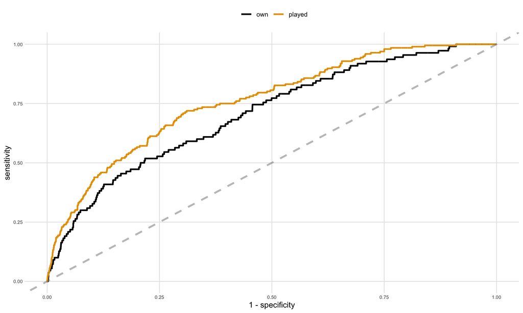

Another way to think about the model performance is to view its lift, or its ability to detect the positive outcomes over that of a null model. High lift indicates the model can much more quickly find all of the positive outcomes (in this case, games owned or played by the user), while a model with no lift is no better than random guessing.

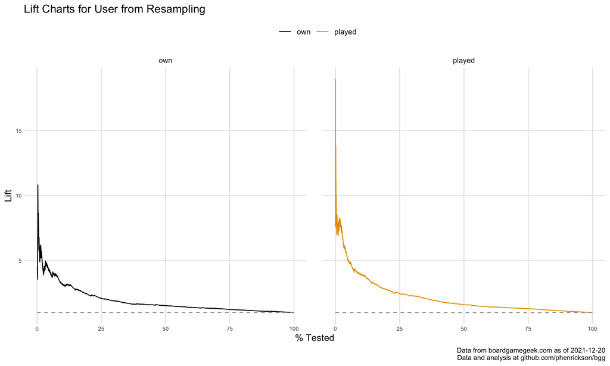

## 3.3 Most and Least Likely Games

What games does the model think jhgf280 is **most likely to own** that are **not** in their collection?

| username | yearpublished | game_id | name | pred_own | actual_own |
| --- | --- | --- | --- | --- | --- |
| jhgf280 | 2014 | 163412 | Patchwork | 0.65 | 0 |
| jhgf280 | 2019 | 283863 | The Magnificent | 0.51 | 0 |
| jhgf280 | 2019 | 270971 | Era: Medieval Age | 0.35 | 0 |
| jhgf280 | 2018 | 205896 | Rising Sun | 0.27 | 0 |
| jhgf280 | 2005 | 16395 | Blokus Duo | 0.22 | 0 |

What games does the model think jhgf280 is **least likely to own** that **are** in their collection?

| username | yearpublished | game_id | name | pred_own | actual_own |
| --- | --- | --- | --- | --- | --- |
| jhgf280 | 1900 | 171 | Chess | 0.01 | 1 |
| jhgf280 | 1999 | 50 | Lost Cities | 0.01 | 1 |
| jhgf280 | 2002 | 3385 | Stratego: Star Wars | 0.01 | 1 |
| jhgf280 | 2011 | 108831 | Kulami | 0.01 | 1 |
| jhgf280 | 2017 | 197443 | Fugitive | 0.01 | 1 |

## 3.4 Top Games by Year

Top 25 games most likely to be owned by the user in each year, highlighting in blue the games that the user has owned/played.

| rank | 2011 | 2012 | 2013 | 2014 | 2015 | 2016 | 2017 | 2018 | 2019 |
| --- | --- | --- | --- | --- | --- | --- | --- | --- | --- |
| 1 | Takenoko | Robinson Crusoe: Adventures on the Cursed Island | Lewis & Clark: The Expedition | Patchwork | 504 | Codenames: Pictures | Gloomhaven | Rising Sun | The Magnificent |
| 2 | Flash Point: Fire Rescue | The Manhattan Project | BANG! The Dice Game | Splendor | Burgle Bros. | Islebound | Codenames: Disney – Family Edition | Decrypto | Era: Medieval Age |
| 3 | Mundus Novus | Space Cadets | Concept | Spyfall | Exploding Kittens: NSFW Deck | Codenames: Deep Undercover | Breaking Bad: The Board Game | Cosmic Run: Regeneration | Amul |
| 4 | Dungeon Fighter | Seasons | Room 25 | Dragon Run | Codenames | When I Dream | Secrets | Forum Trajanum | Last Bastion |
| 5 | Mage Knight Board Game | Kairo | Forbidden Desert | Five Tribes | Dead Man's Draw | Broom Service: The Card Game | Codenames: Duet | Shadows: Amsterdam | Chai |
| 6 | Rumble in the House | Archipelago | Rise of Augustus | Deception: Murder in Hong Kong | Tumult Royale | Citadels | Harvest Dice | Kero | The Isle of Cats |
| 7 | A Few Acres of Snow | Zombicide | The Phantom Society | La Granja | Mysterium | Loot N Run | Pulsar 2849 | Cahoots | Century: A New World |
| 8 | Martian Dice | Android: Infiltration | Impulse | Sheriff of Nottingham | March of the Ants | Black Orchestra | Penguin Trap | Patchwork Express | Noctiluca |
| 9 | Streams | Keyflower | The Ravens of Thri Sahashri | Imperial Settlers | Elysium | Santorini | Magic Maze | Gingerbread House | Paris: La Cité de la Lumière |
| 10 | Struggle for Catan | Rumble in the Dungeon | Longhorn | The Golden Ages | Between Two Cities | Assembly | Tak | Sprawlopolis | One Key |
| 11 | Catan: Junior | Diavolo | Cardline: Globetrotter | DungeonQuest Revised Edition | The Grizzled | The Oregon Trail Card Game | Mythic Battles: Pantheon | Yellow & Yangtze | Naga Raja |
| 12 | Tetris Link | Coup | Quantum | Sheep & Thief | FUSE | Hit Z Road | Sagrada | Realm of Sand | Fire Tower |
| 13 | Rory's Story Cubes: Voyages | Okiya | Thebes: The Tomb Raiders | Gaïa | Blood Rage | Kingdomino | Escape the Dark Castle | Château Aventure | Herbaceous Sprouts |
| 14 | Panic Station | In Magnificent Style: Pickett's Charge at Gettysburg | Bomb Squad | Onitama | Specter Ops | Kanagawa | Exploding Kittens: Party Pack | Nemesis | Minecraft: Builders & Biomes |
| 15 | Tem-Purr-A | Agents of SMERSH | Jungle Speed: Safari | North Wind | Tales & Games: Little Red Riding Hood | Timebomb | Klondike Rush | Codenames: Harry Potter | Butterfly |
| 16 | Laser Chess | Catan: Family Edition | Crossing | Witness | ...and then, we held hands. | Inis | Paper Tales | Dice Hospital | Wavelength |
| 17 | Urban Sprawl | Il Vecchio | Tales & Games: The Three Little Pigs | King of New York | T.I.M.E Stories | Roll Player | King of the Dice | Fireball Island: The Curse of Vul-Kar | The Quest for El Dorado: The Golden Temples |
| 18 | Ninjato | One Night Werewolf | Agent Hunter | One Night Ultimate Werewolf | Barony | Smugglers | Fog of Love | Azul: Stained Glass of Sintra | Tainted Grail: The Fall of Avalon |
| 19 | Shitenno | Dixit: Journey | Pathfinder Adventure Card Game: Rise of the Runelords – Base Set | Istanbul | Karuba | A Game of Thrones: Hand of the King | Yamataï | That's Pretty Clever! | Silver & Gold |
| 20 | Catan Histories: Merchants of Europe | The Resistance: Avalon | City of Remnants | Port Royal | Unusual Suspects | Beyond Baker Street | Rajas of the Ganges | Vengeance | Pandemic: Rapid Response |
| 21 | Ultimate Warriorz | A Fake Artist Goes to New York | Eight-Minute Empire: Legends | Heroes of Normandie | Shadows Over Normandie: Achtung! Cthulhu | HMS Dolores | Unearth | Muse: Awakenings | Tapestry |
| 22 | Trophy Buck | Pocket Battles: Macedonians vs. Persians | Tash-Kalar: Arena of Legends | Haru Ichiban | Salem 1692 | Ominoes | Photosynthesis | Human Punishment: Social Deduction 2.0 | Yukon Airways |
| 23 | Dixit: Odyssey | Urbion | The Builders: Middle Ages | Outfoxed! | Nevermore | The Oracle of Delphi | Azul | Renegade | Aquatica |
| 24 | The Adventurers: The Pyramid of Horus | Mice and Mystics | Welcome to the Dungeon | Good Cop Bad Cop | One Night Revolution | Star Trek: The Dice Game | Sherlock Holmes Consulting Detective: Carlton House & Queen's Park | Specter Ops: Broken Covenant | Nova Luna |
| 25 | King of Tokyo | Star Trek: Catan | Patchistory | Colt Express | A Study in Emerald (Second Edition) | 1572: The Lost Expedition | Codenames: Marvel | Treasure Island | Tuki |

## 3.5 Interactive Predictions from Resampling

Interactive table for predictions from resampling.

|  | username | yearpublished | rank | game_id | name | pred_played | pred_own | actual_played | actual_own |
| --- | --- | --- | --- | --- | --- | --- | --- | --- | --- |
| 1 | jhgf280 | 1900 | 15 | 10213 | Fox and Geese | 0.19 | 0.15 | 0 | 0 |
| 2 | jhgf280 | 1900 | 25 | 2389 | Othello | 0.15 | 0.13 | 1 | 0 |
| 3 | jhgf280 | 1900 | 27 | 2173 | 4 Player Chess | 0.17 | 0.13 | 0 | 0 |
| 4 | jhgf280 | 1900 | 68 | 2065 | Shogi | 0.15 | 0.09 | 0 | 0 |
| 5 | jhgf280 | 1900 | 78 | 2386 | Chinese Checkers | 0.24 | 0.09 | 0 | 0 |
| 6 | jhgf280 | 1900 | 96 | 6424 | Pick Up Sticks | 0.1 | 0.08 | 0 | 0 |
| 7 | jhgf280 | 1900 | 100 | 26952 | International Checkers | 0.13 | 0.07 | 0 | 0 |
| 8 | jhgf280 | 1900 | 120 | 45 | Perudo | 0.22 | 0.07 | 1 | 0 |
| 9 | jhgf280 | 1900 | 129 | 1602 | The Royal Game of Ur | 0.11 | 0.06 | 0 | 0 |
| 10 | jhgf280 | 1900 | 132 | 2448 | Kalah | 0.22 | 0.06 | 0 | 0 |

[output cut: 7426 more lines]

# 4 Validating the Model on 2020

How well did a model trained on a user’s collection through 2019 perform in predicting games for the user from 2020?

| username | outcome_type | yearpublished | .metric | .estimator | .estimate |
| --- | --- | --- | --- | --- | --- |
| jhgf280 | own | 2020 | roc_auc | binary | 0.797 |
| jhgf280 | played | 2020 | roc_auc | binary | 0.794 |

Table of top 25 games from 2020, highlighting games that the user owns.

| username | yearpublished | game_id | name | pred_own | pred_played | actual_own | actual_played |
| --- | --- | --- | --- | --- | --- | --- | --- |
| jhgf280 | 2020 | 184267 | On Mars | 0.22 | 0.33 | 0 | 0 |
| jhgf280 | 2020 | 291457 | Gloomhaven: Jaws of the Lion | 0.18 | 0.22 | 1 | 1 |
| jhgf280 | 2020 | 292333 | Cowboys II: Cowboys & Indians Edition | 0.18 | 0.34 | 0 | 0 |
| jhgf280 | 2020 | 284742 | Honey Buzz | 0.12 | 0.15 | 0 | 0 |
| jhgf280 | 2020 | 315631 | Santorini: New York | 0.10 | 0.16 | 0 | 0 |
| jhgf280 | 2020 | 299592 | Beez | 0.09 | 0.17 | 0 | 0 |
| jhgf280 | 2020 | 301767 | Mysterium Park | 0.09 | 0.15 | 0 | 0 |
| jhgf280 | 2020 | 307844 | Atheneum: Mystic Library | 0.09 | 0.18 | 0 | 0 |
| jhgf280 | 2020 | 320819 | Dinner in Paris | 0.09 | 0.07 | 0 | 0 |
| jhgf280 | 2020 | 316377 | 7 Wonders (Second Edition) | 0.08 | 0.21 | 0 | 0 |
| jhgf280 | 2020 | 256940 | Krosmaster: Blast | 0.07 | 0.13 | 0 | 0 |
| jhgf280 | 2020 | 302465 | Obsidia | 0.07 | 0.15 | 0 | 0 |
| jhgf280 | 2020 | 306040 | Merv: The Heart of the Silk Road | 0.07 | 0.09 | 0 | 0 |
| jhgf280 | 2020 | 323784 | Ghost Letters | 0.07 | 0.12 | 0 | 0 |
| jhgf280 | 2020 | 302840 | Carcata | 0.06 | 0.12 | 0 | 0 |
| jhgf280 | 2020 | 306735 | Under Falling Skies | 0.06 | 0.11 | 0 | 0 |
| jhgf280 | 2020 | 319966 | The King Is Dead: Second Edition | 0.06 | 0.13 | 0 | 0 |
| jhgf280 | 2020 | 236713 | Sea of Plunder | 0.05 | 0.08 | 0 | 0 |
| jhgf280 | 2020 | 245658 | Unicorn Fever | 0.05 | 0.05 | 0 | 0 |
| jhgf280 | 2020 | 256589 | Rallyman: GT | 0.05 | 0.06 | 0 | 0 |
| jhgf280 | 2020 | 262274 | D6: Dungeons, Dudes, Dames, Danger, Dice and Dragons! | 0.05 | 0.07 | 0 | 0 |
| jhgf280 | 2020 | 271002 | Myraclia | 0.05 | 0.09 | 0 | 0 |
| jhgf280 | 2020 | 293296 | Splendor: Marvel | 0.05 | 0.04 | 0 | 0 |
| jhgf280 | 2020 | 295948 | Aqualin | 0.05 | 0.11 | 0 | 0 |
| jhgf280 | 2020 | 314040 | Pandemic Legacy: Season 0 | 0.05 | 0.09 | 0 | 0 |

# 5 Predicting Upcoming Games (2020 and On) for **jhgf280**

Examine the top games for the test set.

| username | yearpublished | game_id | name | rank | own | played |
| --- | --- | --- | --- | --- | --- | --- |
| jhgf280 | 2020 | 184267 | On Mars | 1 | 0.22 | 0.33 |
| jhgf280 | 2020 | 292333 | Cowboys II: Cowboys & Indians Edition | 2 | 0.18 | 0.34 |
| jhgf280 | 2020 | 291457 | Gloomhaven: Jaws of the Lion | 3 | 0.18 | 0.22 |
| jhgf280 | 2020 | 284742 | Honey Buzz | 4 | 0.12 | 0.15 |
| jhgf280 | 2020 | 315631 | Santorini: New York | 5 | 0.10 | 0.16 |
| jhgf280 | 2020 | 320819 | Dinner in Paris | 6 | 0.09 | 0.07 |
| jhgf280 | 2020 | 299592 | Beez | 7 | 0.09 | 0.17 |
| jhgf280 | 2020 | 307844 | Atheneum: Mystic Library | 8 | 0.09 | 0.18 |
| jhgf280 | 2020 | 301767 | Mysterium Park | 9 | 0.09 | 0.15 |
| jhgf280 | 2020 | 316377 | 7 Wonders (Second Edition) | 10 | 0.08 | 0.21 |
| jhgf280 | 2020 | 323784 | Ghost Letters | 11 | 0.07 | 0.12 |
| jhgf280 | 2020 | 256940 | Krosmaster: Blast | 12 | 0.07 | 0.13 |
| jhgf280 | 2020 | 306040 | Merv: The Heart of the Silk Road | 13 | 0.07 | 0.09 |
| jhgf280 | 2020 | 302465 | Obsidia | 14 | 0.07 | 0.15 |
| jhgf280 | 2020 | 302840 | Carcata | 15 | 0.06 | 0.12 |
| jhgf280 | 2020 | 319966 | The King Is Dead: Second Edition | 16 | 0.06 | 0.13 |
| jhgf280 | 2020 | 306735 | Under Falling Skies | 17 | 0.06 | 0.11 |
| jhgf280 | 2020 | 314040 | Pandemic Legacy: Season 0 | 18 | 0.05 | 0.09 |
| jhgf280 | 2020 | 293296 | Splendor: Marvel | 19 | 0.05 | 0.04 |
| jhgf280 | 2020 | 262274 | D6: Dungeons, Dudes, Dames, Danger, Dice and Dragons! | 20 | 0.05 | 0.07 |
| jhgf280 | 2020 | 271002 | Myraclia | 21 | 0.05 | 0.09 |
| jhgf280 | 2020 | 236713 | Sea of Plunder | 22 | 0.05 | 0.08 |
| jhgf280 | 2020 | 318472 | Blood Bowl: Second Season Edition | 23 | 0.05 | 0.04 |
| jhgf280 | 2020 | 245658 | Unicorn Fever | 24 | 0.05 | 0.05 |
| jhgf280 | 2020 | 256589 | Rallyman: GT | 25 | 0.05 | 0.06 |
| jhgf280 | 2021 | 298102 | Roll Camera!: The Filmmaking Board Game | 1 | 0.21 | 0.38 |
| jhgf280 | 2021 | 291859 | Riftforce | 2 | 0.15 | 0.29 |
| jhgf280 | 2021 | 319999 | Dungeon Decorators | 3 | 0.13 | 0.20 |
| jhgf280 | 2021 | 305761 | Whale Riders | 4 | 0.09 | 0.06 |
| jhgf280 | 2021 | 252752 | Genotype: A Mendelian Genetics Game | 5 | 0.09 | 0.13 |
| jhgf280 | 2021 | 318996 | Welcome to Sysifus Corp | 6 | 0.08 | 0.09 |
| jhgf280 | 2021 | 341358 | INSERT | 7 | 0.08 | 0.13 |
| jhgf280 | 2021 | 285967 | Ankh: Gods of Egypt | 8 | 0.08 | 0.10 |
| jhgf280 | 2021 | 310873 | Carnegie | 9 | 0.08 | 0.19 |
| jhgf280 | 2021 | 249277 | Brazil: Imperial | 10 | 0.08 | 0.12 |
| jhgf280 | 2021 | 343905 | Boonlake | 11 | 0.07 | 0.07 |
| jhgf280 | 2021 | 319792 | Fly-A-Way | 12 | 0.07 | 0.05 |
| jhgf280 | 2021 | 313269 | Rescuing Robin Hood | 13 | 0.07 | 0.13 |
| jhgf280 | 2021 | 319263 | One Card Dungeon | 14 | 0.07 | 0.13 |
| jhgf280 | 2021 | 307862 | Dollars to Donuts | 15 | 0.07 | 0.21 |
| jhgf280 | 2021 | 295947 | Cascadia | 16 | 0.06 | 0.21 |
| jhgf280 | 2021 | 336195 | League of Dungeoneers | 17 | 0.06 | 0.08 |
| jhgf280 | 2021 | 344258 | That Time You Killed Me | 18 | 0.06 | 0.13 |
| jhgf280 | 2021 | 317312 | Kombo Klash! | 19 | 0.06 | 0.12 |
| jhgf280 | 2021 | 341233 | Almadi | 20 | 0.06 | 0.15 |
| jhgf280 | 2021 | 314088 | Agropolis | 21 | 0.06 | 0.19 |
| jhgf280 | 2021 | 308989 | Bristol 1350 | 22 | 0.06 | 0.10 |
| jhgf280 | 2021 | 340041 | Kingdomino Origins | 23 | 0.06 | 0.10 |
| jhgf280 | 2021 | 335541 | We Care: a Grizzled Game | 24 | 0.06 | 0.10 |
| jhgf280 | 2021 | 320992 | The Specialists | 25 | 0.06 | 0.08 |
| jhgf280 | 2022 | 331106 | The Witcher: Old World | 1 | 0.11 | 0.10 |
| jhgf280 | 2022 | 295770 | Frosthaven | 2 | 0.08 | 0.13 |
| jhgf280 | 2022 | 334065 | Verdant | 3 | 0.07 | 0.24 |
| jhgf280 | 2022 | 338067 | 6: Siege – The Board Game | 4 | 0.05 | 0.06 |
| jhgf280 | 2022 | 304051 | Creature Comforts | 5 | 0.05 | 0.08 |
| jhgf280 | 2022 | 312959 | Rallyman: DIRT | 6 | 0.05 | 0.06 |
| jhgf280 | 2022 | 322524 | Bardsung | 7 | 0.04 | 0.05 |
| jhgf280 | 2022 | 283137 | Human Punishment: The Beginning | 8 | 0.04 | 0.08 |
| jhgf280 | 2022 | 322289 | Darwin's Journey | 9 | 0.03 | 0.02 |
| jhgf280 | 2022 | 336986 | Flamecraft | 10 | 0.03 | 0.03 |
| jhgf280 | 2022 | 305462 | The Age of Atlantis | 11 | 0.03 | 0.03 |
| jhgf280 | 2022 | 256680 | Return to Dark Tower | 12 | 0.03 | 0.04 |
| jhgf280 | 2022 | 317511 | Tindaya | 13 | 0.03 | 0.05 |
| jhgf280 | 2022 | 284189 | Foundations of Rome | 14 | 0.03 | 0.05 |
| jhgf280 | 2022 | 295374 | Long Shot: The Dice Game | 15 | 0.03 | 0.04 |
| jhgf280 | 2022 | 281647 | Stellaris: Infinite Legacy | 16 | 0.02 | 0.02 |
| jhgf280 | 2022 | 326945 | Castles of Mad King Ludwig: Collector's Edition | 17 | 0.02 | 0.03 |
| jhgf280 | 2022 | 295895 | Distilled | 18 | 0.02 | 0.02 |
| jhgf280 | 2022 | 322564 | Fjords | 19 | 0.02 | 0.03 |
| jhgf280 | 2022 | 322589 | Zapotec | 20 | 0.02 | 0.03 |
| jhgf280 | 2022 | 294880 | Chai: Tea for 2 | 21 | 0.02 | 0.03 |
| jhgf280 | 2022 | 311823 | Nova Aetas Renaissance | 22 | 0.02 | 0.04 |
| jhgf280 | 2022 | 342246 | Feuding Foodies | 23 | 0.02 | 0.04 |
| jhgf280 | 2022 | 293941 | Mage Noir | 24 | 0.02 | 0.03 |
| jhgf280 | 2022 | 258779 | Planet Unknown | 25 | 0.02 | 0.05 |

## 5.1 Interactive Table for Upcoming Games 2020 and On

|  | username | yearpublished | game_id | name | rank | own | played |
| --- | --- | --- | --- | --- | --- | --- | --- |
| 1 | jhgf280 | 2020 | 184267 | On Mars | 1 | 0.22 | 0.33 |
| 2 | jhgf280 | 2021 | 298102 | Roll Camera!: The Filmmaking Board Game | 2 | 0.21 | 0.38 |
| 3 | jhgf280 | 2020 | 292333 | Cowboys II: Cowboys &amp; Indians Edition | 3 | 0.18 | 0.34 |
| 4 | jhgf280 | 2020 | 291457 | Gloomhaven: Jaws of the Lion | 4 | 0.18 | 0.22 |
| 5 | jhgf280 | 2021 | 291859 | Riftforce | 5 | 0.15 | 0.29 |
| 6 | jhgf280 | 2021 | 319999 | Dungeon Decorators | 6 | 0.13 | 0.2 |
| 7 | jhgf280 | 2020 | 284742 | Honey Buzz | 7 | 0.12 | 0.15 |
| 8 | jhgf280 | 2022 | 331106 | The Witcher: Old World | 8 | 0.11 | 0.1 |
| 9 | jhgf280 | 2020 | 315631 | Santorini: New York | 9 | 0.1 | 0.16 |
| 10 | jhgf280 | 2021 | 305761 | Whale Riders | 10 | 0.09 | 0.06 |

[output cut: 1627 more lines]